# Risk Factor Analysis

## Outcome Variable

**Outcome Variable:** wast_rec90d

## Predictor Variables

**Intervention Variable:** birthlen

**Adjustment Set:**

- arm
- sex
- W_mage
- meducyrs
- feducyrs
- vagbrth
- brthmon
- W_parity
- impsan
- delta_W_mage
- delta_meducyrs
- delta_feducyrs
- delta_vagbrth
- delta_brthmon
- delta_W_parity
- delta_impsan

## Stratifying Variables

The analysis was stratified on these variable(s):

- agecat
- studyid
- country

## Data Summary

| agecat | studyid | country | birthlen | wast_rec90d | n_cell | n |
| --- | --- | --- | --- | --- | --- | --- |
| 0-24 months | ki0047075b-MAL-ED | BANGLADESH | >=50 cm | 0 | 4 | 119 |
| 0-24 months | ki0047075b-MAL-ED | BANGLADESH | >=50 cm | 1 | 12 | 119 |
| 0-24 months | ki0047075b-MAL-ED | BANGLADESH | <48 cm | 0 | 25 | 119 |
| 0-24 months | ki0047075b-MAL-ED | BANGLADESH | <48 cm | 1 | 43 | 119 |
| 0-24 months | ki0047075b-MAL-ED | BANGLADESH | [48-50) cm | 0 | 15 | 119 |
| 0-24 months | ki0047075b-MAL-ED | BANGLADESH | [48-50) cm | 1 | 20 | 119 |
| 0-24 months | ki0047075b-MAL-ED | BRAZIL | >=50 cm | 0 | 0 | 22 |
| 0-24 months | ki0047075b-MAL-ED | BRAZIL | >=50 cm | 1 | 6 | 22 |
| 0-24 months | ki0047075b-MAL-ED | BRAZIL | <48 cm | 0 | 3 | 22 |
| 0-24 months | ki0047075b-MAL-ED | BRAZIL | <48 cm | 1 | 6 | 22 |
| 0-24 months | ki0047075b-MAL-ED | BRAZIL | [48-50) cm | 0 | 2 | 22 |
| 0-24 months | ki0047075b-MAL-ED | BRAZIL | [48-50) cm | 1 | 5 | 22 |
| 0-24 months | ki0047075b-MAL-ED | INDIA | >=50 cm | 0 | 3 | 144 |
| 0-24 months | ki0047075b-MAL-ED | INDIA | >=50 cm | 1 | 9 | 144 |
| 0-24 months | ki0047075b-MAL-ED | INDIA | <48 cm | 0 | 35 | 144 |
| 0-24 months | ki0047075b-MAL-ED | INDIA | <48 cm | 1 | 45 | 144 |
| 0-24 months | ki0047075b-MAL-ED | INDIA | [48-50) cm | 0 | 19 | 144 |
| 0-24 months | ki0047075b-MAL-ED | INDIA | [48-50) cm | 1 | 33 | 144 |
| 0-24 months | ki0047075b-MAL-ED | NEPAL | >=50 cm | 0 | 4 | 72 |
| 0-24 months | ki0047075b-MAL-ED | NEPAL | >=50 cm | 1 | 8 | 72 |
| 0-24 months | ki0047075b-MAL-ED | NEPAL | <48 cm | 0 | 8 | 72 |
| 0-24 months | ki0047075b-MAL-ED | NEPAL | <48 cm | 1 | 38 | 72 |
| 0-24 months | ki0047075b-MAL-ED | NEPAL | [48-50) cm | 0 | 1 | 72 |
| 0-24 months | ki0047075b-MAL-ED | NEPAL | [48-50) cm | 1 | 13 | 72 |
| 0-24 months | ki0047075b-MAL-ED | PERU | >=50 cm | 0 | 0 | 34 |
| 0-24 months | ki0047075b-MAL-ED | PERU | >=50 cm | 1 | 4 | 34 |
| 0-24 months | ki0047075b-MAL-ED | PERU | <48 cm | 0 | 5 | 34 |
| 0-24 months | ki0047075b-MAL-ED | PERU | <48 cm | 1 | 17 | 34 |
| 0-24 months | ki0047075b-MAL-ED | PERU | [48-50) cm | 0 | 1 | 34 |
| 0-24 months | ki0047075b-MAL-ED | PERU | [48-50) cm | 1 | 7 | 34 |

[output cut: 444 more lines]

The following strata were considered:

- agecat: 0-24 months, studyid: ki0047075b-MAL-ED, country: BANGLADESH
- agecat: 0-24 months, studyid: ki0047075b-MAL-ED, country: BRAZIL
- agecat: 0-24 months, studyid: ki0047075b-MAL-ED, country: INDIA
- agecat: 0-24 months, studyid: ki0047075b-MAL-ED, country: NEPAL
- agecat: 0-24 months, studyid: ki0047075b-MAL-ED, country: PERU
- agecat: 0-24 months, studyid: ki0047075b-MAL-ED, country: SOUTH AFRICA
- agecat: 0-24 months, studyid: ki0047075b-MAL-ED, country: TANZANIA, UNITED REPUBLIC OF
- agecat: 0-24 months, studyid: ki1000108-CMC-V-BCS-2002, country: INDIA
- agecat: 0-24 months, studyid: ki1000108-IRC, country: INDIA
- agecat: 0-24 months, studyid: ki1000109-EE, country: PAKISTAN
- agecat: 0-24 months, studyid: ki1000109-ResPak, country: PAKISTAN
- agecat: 0-24 months, studyid: ki1000304b-SAS-CompFeed, country: INDIA
- agecat: 0-24 months, studyid: ki1017093-NIH-Birth, country: BANGLADESH
- agecat: 0-24 months, studyid: ki1017093b-PROVIDE, country: BANGLADESH
- agecat: 0-24 months, studyid: ki1017093c-NIH-Crypto, country: BANGLADESH
- agecat: 0-24 months, studyid: ki1101329-Keneba, country: GAMBIA
- agecat: 0-24 months, studyid: ki1114097-CMIN, country: BANGLADESH
- agecat: 0-24 months, studyid: ki1114097-CMIN, country: BRAZIL
- agecat: 0-24 months, studyid: ki1114097-CMIN, country: GUINEA-BISSAU
- agecat: 0-24 months, studyid: ki1114097-CMIN, country: PERU
- agecat: 0-24 months, studyid: ki1119695-PROBIT, country: BELARUS
- agecat: 0-24 months, studyid: ki1126311-ZVITAMBO, country: ZIMBABWE
- agecat: 0-24 months, studyid: ki1135781-COHORTS, country: GUATEMALA
- agecat: 0-24 months, studyid: ki1135781-COHORTS, country: INDIA
- agecat: 0-24 months, studyid: ki1135781-COHORTS, country: PHILIPPINES
- agecat: 0-24 months, studyid: kiGH5241-JiVitA-3, country: BANGLADESH
- agecat: 0-24 months, studyid: kiGH5241-JiVitA-4, country: BANGLADESH
- agecat: 0-6 months, studyid: ki0047075b-MAL-ED, country: BANGLADESH
- agecat: 0-6 months, studyid: ki0047075b-MAL-ED, country: BRAZIL
- agecat: 0-6 months, studyid: ki0047075b-MAL-ED, country: INDIA
- agecat: 0-6 months, studyid: ki0047075b-MAL-ED, country: NEPAL
- agecat: 0-6 months, studyid: ki0047075b-MAL-ED, country: PERU
- agecat: 0-6 months, studyid: ki0047075b-MAL-ED, country: SOUTH AFRICA
- agecat: 0-6 months, studyid: ki0047075b-MAL-ED, country: TANZANIA, UNITED REPUBLIC OF
- agecat: 0-6 months, studyid: ki1000108-CMC-V-BCS-2002, country: INDIA
- agecat: 0-6 months, studyid: ki1000108-IRC, country: INDIA
- agecat: 0-6 months, studyid: ki1000109-EE, country: PAKISTAN
- agecat: 0-6 months, studyid: ki1000109-ResPak, country: PAKISTAN
- agecat: 0-6 months, studyid: ki1000304b-SAS-CompFeed, country: INDIA
- agecat: 0-6 months, studyid: ki1017093-NIH-Birth, country: BANGLADESH
- agecat: 0-6 months, studyid: ki1017093b-PROVIDE, country: BANGLADESH
- agecat: 0-6 months, studyid: ki1017093c-NIH-Crypto, country: BANGLADESH
- agecat: 0-6 months, studyid: ki1101329-Keneba, country: GAMBIA
- agecat: 0-6 months, studyid: ki1114097-CMIN, country: BANGLADESH
- agecat: 0-6 months, studyid: ki1114097-CMIN, country: BRAZIL
- agecat: 0-6 months, studyid: ki1114097-CMIN, country: GUINEA-BISSAU
- agecat: 0-6 months, studyid: ki1114097-CMIN, country: PERU
- agecat: 0-6 months, studyid: ki1119695-PROBIT, country: BELARUS
- agecat: 0-6 months, studyid: ki1126311-ZVITAMBO, country: ZIMBABWE
- agecat: 0-6 months, studyid: ki1135781-COHORTS, country: GUATEMALA
- agecat: 0-6 months, studyid: ki1135781-COHORTS, country: INDIA
- agecat: 0-6 months, studyid: ki1135781-COHORTS, country: PHILIPPINES
- agecat: 0-6 months, studyid: kiGH5241-JiVitA-3, country: BANGLADESH
- agecat: 0-6 months, studyid: kiGH5241-JiVitA-4, country: BANGLADESH
- agecat: 6-24 months, studyid: ki0047075b-MAL-ED, country: BANGLADESH
- agecat: 6-24 months, studyid: ki0047075b-MAL-ED, country: BRAZIL
- agecat: 6-24 months, studyid: ki0047075b-MAL-ED, country: INDIA
- agecat: 6-24 months, studyid: ki0047075b-MAL-ED, country: NEPAL
- agecat: 6-24 months, studyid: ki0047075b-MAL-ED, country: PERU
- agecat: 6-24 months, studyid: ki0047075b-MAL-ED, country: SOUTH AFRICA
- agecat: 6-24 months, studyid: ki0047075b-MAL-ED, country: TANZANIA, UNITED REPUBLIC OF
- agecat: 6-24 months, studyid: ki1000108-CMC-V-BCS-2002, country: INDIA
- agecat: 6-24 months, studyid: ki1000108-IRC, country: INDIA
- agecat: 6-24 months, studyid: ki1000109-EE, country: PAKISTAN
- agecat: 6-24 months, studyid: ki1000109-ResPak, country: PAKISTAN
- agecat: 6-24 months, studyid: ki1000304b-SAS-CompFeed, country: INDIA
- agecat: 6-24 months, studyid: ki1017093-NIH-Birth, country: BANGLADESH
- agecat: 6-24 months, studyid: ki1017093b-PROVIDE, country: BANGLADESH
- agecat: 6-24 months, studyid: ki1017093c-NIH-Crypto, country: BANGLADESH
- agecat: 6-24 months, studyid: ki1101329-Keneba, country: GAMBIA
- agecat: 6-24 months, studyid: ki1114097-CMIN, country: BRAZIL
- agecat: 6-24 months, studyid: ki1114097-CMIN, country: PERU
- agecat: 6-24 months, studyid: ki1119695-PROBIT, country: BELARUS
- agecat: 6-24 months, studyid: ki1126311-ZVITAMBO, country: ZIMBABWE
- agecat: 6-24 months, studyid: ki1135781-COHORTS, country: GUATEMALA
- agecat: 6-24 months, studyid: ki1135781-COHORTS, country: INDIA
- agecat: 6-24 months, studyid: ki1135781-COHORTS, country: PHILIPPINES
- agecat: 6-24 months, studyid: kiGH5241-JiVitA-3, country: BANGLADESH
- agecat: 6-24 months, studyid: kiGH5241-JiVitA-4, country: BANGLADESH

### Dropped Strata

Some strata were dropped due to rare outcomes:

- agecat: 0-24 months, studyid: ki0047075b-MAL-ED, country: BANGLADESH
- agecat: 0-24 months, studyid: ki0047075b-MAL-ED, country: BRAZIL
- agecat: 0-24 months, studyid: ki0047075b-MAL-ED, country: INDIA
- agecat: 0-24 months, studyid: ki0047075b-MAL-ED, country: NEPAL
- agecat: 0-24 months, studyid: ki0047075b-MAL-ED, country: PERU
- agecat: 0-24 months, studyid: ki0047075b-MAL-ED, country: SOUTH AFRICA
- agecat: 0-24 months, studyid: ki0047075b-MAL-ED, country: TANZANIA, UNITED REPUBLIC OF
- agecat: 0-24 months, studyid: ki1000108-CMC-V-BCS-2002, country: INDIA
- agecat: 0-24 months, studyid: ki1000109-ResPak, country: PAKISTAN
- agecat: 0-24 months, studyid: ki1114097-CMIN, country: BANGLADESH
- agecat: 0-24 months, studyid: ki1114097-CMIN, country: BRAZIL
- agecat: 0-24 months, studyid: ki1114097-CMIN, country: GUINEA-BISSAU
- agecat: 0-24 months, studyid: ki1114097-CMIN, country: PERU
- agecat: 0-6 months, studyid: ki0047075b-MAL-ED, country: BANGLADESH
- agecat: 0-6 months, studyid: ki0047075b-MAL-ED, country: BRAZIL
- agecat: 0-6 months, studyid: ki0047075b-MAL-ED, country: INDIA
- agecat: 0-6 months, studyid: ki0047075b-MAL-ED, country: NEPAL
- agecat: 0-6 months, studyid: ki0047075b-MAL-ED, country: PERU
- agecat: 0-6 months, studyid: ki0047075b-MAL-ED, country: SOUTH AFRICA
- agecat: 0-6 months, studyid: ki0047075b-MAL-ED, country: TANZANIA, UNITED REPUBLIC OF
- agecat: 0-6 months, studyid: ki1000108-CMC-V-BCS-2002, country: INDIA
- agecat: 0-6 months, studyid: ki1000109-EE, country: PAKISTAN
- agecat: 0-6 months, studyid: ki1000109-ResPak, country: PAKISTAN
- agecat: 0-6 months, studyid: ki1017093-NIH-Birth, country: BANGLADESH
- agecat: 0-6 months, studyid: ki1017093c-NIH-Crypto, country: BANGLADESH
- agecat: 0-6 months, studyid: ki1114097-CMIN, country: BANGLADESH
- agecat: 0-6 months, studyid: ki1114097-CMIN, country: BRAZIL
- agecat: 0-6 months, studyid: ki1114097-CMIN, country: GUINEA-BISSAU
- agecat: 0-6 months, studyid: ki1114097-CMIN, country: PERU
- agecat: 6-24 months, studyid: ki0047075b-MAL-ED, country: BANGLADESH
- agecat: 6-24 months, studyid: ki0047075b-MAL-ED, country: BRAZIL
- agecat: 6-24 months, studyid: ki0047075b-MAL-ED, country: INDIA
- agecat: 6-24 months, studyid: ki0047075b-MAL-ED, country: NEPAL
- agecat: 6-24 months, studyid: ki0047075b-MAL-ED, country: PERU
- agecat: 6-24 months, studyid: ki0047075b-MAL-ED, country: SOUTH AFRICA
- agecat: 6-24 months, studyid: ki0047075b-MAL-ED, country: TANZANIA, UNITED REPUBLIC OF
- agecat: 6-24 months, studyid: ki1000108-CMC-V-BCS-2002, country: INDIA
- agecat: 6-24 months, studyid: ki1000109-EE, country: PAKISTAN
- agecat: 6-24 months, studyid: ki1000109-ResPak, country: PAKISTAN
- agecat: 6-24 months, studyid: ki1017093-NIH-Birth, country: BANGLADESH
- agecat: 6-24 months, studyid: ki1017093b-PROVIDE, country: BANGLADESH
- agecat: 6-24 months, studyid: ki1017093c-NIH-Crypto, country: BANGLADESH
- agecat: 6-24 months, studyid: ki1114097-CMIN, country: BRAZIL
- agecat: 6-24 months, studyid: ki1114097-CMIN, country: PERU
- agecat: 6-24 months, studyid: ki1119695-PROBIT, country: BELARUS
- agecat: 6-24 months, studyid: ki1135781-COHORTS, country: GUATEMALA
- agecat: 6-24 months, studyid: ki1135781-COHORTS, country: INDIA
- agecat: 6-24 months, studyid: kiGH5241-JiVitA-3, country: BANGLADESH

## Methods Detail

We’re interested in the causal parameters $E[Y_a]$ for all values of $a \in \mathcal{A}$. These parameters represent the mean outcome if, possibly contrary to fact, we intervened to set all units to have $A=a$. Under the randomization and positivity assumptions, these are identified by the statistical parameters $\psi_a=E_W[E_{Y|A,W}(Y|A=a,W)]$. In addition, we’re interested in the mean of $Y$, $E[Y]$ under no intervention (the observed mean). We will estimate these parameters by using SuperLearner to fit the relevant likelihood factors – $E_{Y|A,W}(Y|A=a,W)$ and $p(A=a|W)$, and then updating our likelihood fit using a joint TMLE.

For unadjusted analyses ($W=\{\}$), initial likelihoods were estimated using Lrnr_glm to estimate the simple $E(Y|A)$ and Lrnr_mean to estimate $p(A)$. For adjusted analyses, a small library containing Lrnr_glmnet, Lrnr_xgboost, and Lrnr_mean was used.

Having estimated these parameters, we will then use the delta method to estimate relative risks and attributable risks relative to a prespecified baseline level of $A$.

# Results Detail

## Results Plots

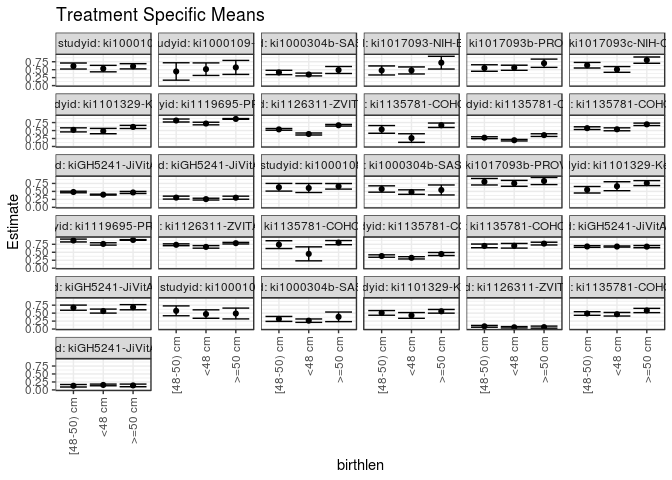

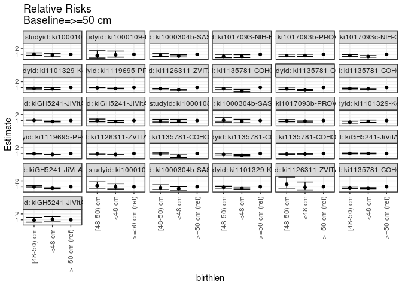

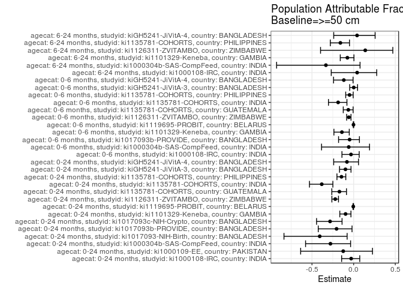

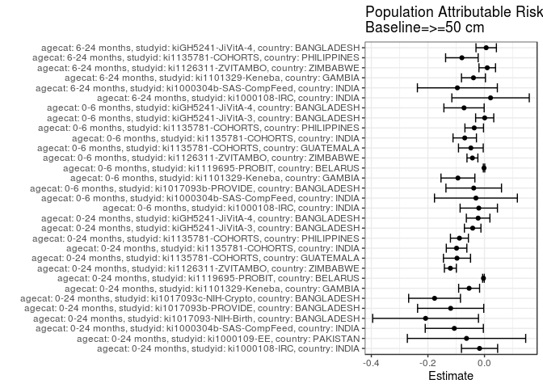

## Results Table

### Parameter: TSM

| agecat | studyid | country | intervention_level | baseline_level | estimate | ci_lower | ci_upper |
| --- | --- | --- | --- | --- | --- | --- | --- |
| 0-24 months | ki1000108-IRC | INDIA | >=50 cm | NA | 0.6065706 | 0.5242196 | 0.6889215 |
| 0-24 months | ki1000108-IRC | INDIA | <48 cm | NA | 0.5340446 | 0.4321063 | 0.6359829 |
| 0-24 months | ki1000108-IRC | INDIA | [48-50) cm | NA | 0.6148643 | 0.5199939 | 0.7097347 |
| 0-24 months | ki1000109-EE | PAKISTAN | >=50 cm | NA | 0.5714286 | 0.3517642 | 0.7910929 |
| 0-24 months | ki1000109-EE | PAKISTAN | <48 cm | NA | 0.5161290 | 0.3192140 | 0.7130441 |
| 0-24 months | ki1000109-EE | PAKISTAN | [48-50) cm | NA | 0.4444444 | 0.1710271 | 0.7178618 |
| 0-24 months | ki1000304b-SAS-CompFeed | INDIA | >=50 cm | NA | 0.4898797 | 0.3796229 | 0.6001365 |
| 0-24 months | ki1000304b-SAS-CompFeed | INDIA | <48 cm | NA | 0.3486865 | 0.3046439 | 0.3927291 |
| 0-24 months | ki1000304b-SAS-CompFeed | INDIA | [48-50) cm | NA | 0.4126462 | 0.3449765 | 0.4803159 |
| 0-24 months | ki1017093-NIH-Birth | BANGLADESH | >=50 cm | NA | 0.7200000 | 0.5200875 | 0.9199125 |
| 0-24 months | ki1017093-NIH-Birth | BANGLADESH | <48 cm | NA | 0.4756098 | 0.3649515 | 0.5862680 |
| 0-24 months | ki1017093-NIH-Birth | BANGLADESH | [48-50) cm | NA | 0.4761905 | 0.3342656 | 0.6181153 |
| 0-24 months | ki1017093b-PROVIDE | BANGLADESH | >=50 cm | NA | 0.7026209 | 0.5731540 | 0.8320877 |
| 0-24 months | ki1017093b-PROVIDE | BANGLADESH | <48 cm | NA | 0.5605693 | 0.4802054 | 0.6409332 |
| 0-24 months | ki1017093b-PROVIDE | BANGLADESH | [48-50) cm | NA | 0.5523598 | 0.4502950 | 0.6544246 |
| 0-24 months | ki1017093c-NIH-Crypto | BANGLADESH | >=50 cm | NA | 0.8002721 | 0.7018632 | 0.8986809 |
| 0-24 months | ki1017093c-NIH-Crypto | BANGLADESH | <48 cm | NA | 0.5079686 | 0.4176455 | 0.5982918 |
| 0-24 months | ki1017093c-NIH-Crypto | BANGLADESH | [48-50) cm | NA | 0.6403474 | 0.5528654 | 0.7278293 |
| 0-24 months | ki1101329-Keneba | GAMBIA | >=50 cm | NA | 0.6136181 | 0.5640674 | 0.6631688 |
| 0-24 months | ki1101329-Keneba | GAMBIA | <48 cm | NA | 0.4838452 | 0.4000390 | 0.5676513 |
| 0-24 months | ki1101329-Keneba | GAMBIA | [48-50) cm | NA | 0.5217758 | 0.4580298 | 0.5855219 |
| 0-24 months | ki1119695-PROBIT | BELARUS | >=50 cm | NA | 0.8648064 | 0.8544839 | 0.8751288 |
| 0-24 months | ki1119695-PROBIT | BELARUS | <48 cm | NA | 0.7200000 | 0.6794039 | 0.7605961 |
| 0-24 months | ki1119695-PROBIT | BELARUS | [48-50) cm | NA | 0.8152610 | 0.7681659 | 0.8623562 |
| 0-24 months | ki1126311-ZVITAMBO | ZIMBABWE | >=50 cm | NA | 0.6665644 | 0.6405284 | 0.6926005 |
| 0-24 months | ki1126311-ZVITAMBO | ZIMBABWE | <48 cm | NA | 0.3916117 | 0.3601176 | 0.4231058 |
| 0-24 months | ki1126311-ZVITAMBO | ZIMBABWE | [48-50) cm | NA | 0.5364245 | 0.5095793 | 0.5632697 |
| 0-24 months | ki1135781-COHORTS | GUATEMALA | >=50 cm | NA | 0.6666370 | 0.5966644 | 0.7366096 |
| 0-24 months | ki1135781-COHORTS | GUATEMALA | <48 cm | NA | 0.2642675 | 0.1299681 | 0.3985669 |
| 0-24 months | ki1135781-COHORTS | GUATEMALA | [48-50) cm | NA | 0.5355180 | 0.4148425 | 0.6561934 |

[output cut: 63 more lines]

### Parameter: E(Y)

| agecat | studyid | country | intervention_level | baseline_level | estimate | ci_lower | ci_upper |
| --- | --- | --- | --- | --- | --- | --- | --- |
| 0-24 months | ki1000108-IRC | INDIA | NA | NA | 0.5891473 | 0.5364145 | 0.6418800 |
| 0-24 months | ki1000109-EE | PAKISTAN | NA | NA | 0.5079365 | 0.3724516 | 0.6434214 |
| 0-24 months | ki1000304b-SAS-CompFeed | INDIA | NA | NA | 0.3831891 | 0.3479331 | 0.4184451 |
| 0-24 months | ki1017093-NIH-Birth | BANGLADESH | NA | NA | 0.5117647 | 0.4302715 | 0.5932579 |
| 0-24 months | ki1017093b-PROVIDE | BANGLADESH | NA | NA | 0.5830619 | 0.5262762 | 0.6398476 |
| 0-24 months | ki1017093c-NIH-Crypto | BANGLADESH | NA | NA | 0.6237942 | 0.5698223 | 0.6777662 |
| 0-24 months | ki1101329-Keneba | GAMBIA | NA | NA | 0.5593036 | 0.5241177 | 0.5944895 |
| 0-24 months | ki1119695-PROBIT | BELARUS | NA | NA | 0.8612051 | 0.8511051 | 0.8713052 |
| 0-24 months | ki1126311-ZVITAMBO | ZIMBABWE | NA | NA | 0.5459916 | 0.5294878 | 0.5624953 |
| 0-24 months | ki1135781-COHORTS | GUATEMALA | NA | NA | 0.5694915 | 0.5120418 | 0.6269413 |
| 0-24 months | ki1135781-COHORTS | INDIA | NA | NA | 0.2579095 | 0.2406335 | 0.2751855 |
| 0-24 months | ki1135781-COHORTS | PHILIPPINES | NA | NA | 0.6067616 | 0.5822457 | 0.6312775 |
| 0-24 months | kiGH5241-JiVitA-3 | BANGLADESH | NA | NA | 0.4249094 | 0.4136873 | 0.4361315 |
| 0-24 months | kiGH5241-JiVitA-4 | BANGLADESH | NA | NA | 0.2796610 | 0.2580570 | 0.3012650 |
| 0-6 months | ki1000108-IRC | INDIA | NA | NA | 0.6398305 | 0.5770134 | 0.7026476 |
| 0-6 months | ki1000304b-SAS-CompFeed | INDIA | NA | NA | 0.5147059 | 0.4610948 | 0.5683169 |
| 0-6 months | ki1017093b-PROVIDE | BANGLADESH | NA | NA | 0.7880435 | 0.7295878 | 0.8464992 |
| 0-6 months | ki1101329-Keneba | GAMBIA | NA | NA | 0.6666667 | 0.6089363 | 0.7243970 |
| 0-6 months | ki1119695-PROBIT | BELARUS | NA | NA | 0.8855266 | 0.8758983 | 0.8951550 |
| 0-6 months | ki1126311-ZVITAMBO | ZIMBABWE | NA | NA | 0.7430390 | 0.7259692 | 0.7601088 |
| 0-6 months | ki1135781-COHORTS | GUATEMALA | NA | NA | 0.7547170 | 0.6968087 | 0.8126253 |
| 0-6 months | ki1135781-COHORTS | INDIA | NA | NA | 0.3750728 | 0.3521661 | 0.3979795 |
| 0-6 months | ki1135781-COHORTS | PHILIPPINES | NA | NA | 0.7363515 | 0.7047428 | 0.7679603 |
| 0-6 months | kiGH5241-JiVitA-3 | BANGLADESH | NA | NA | 0.6779443 | 0.6645427 | 0.6913460 |
| 0-6 months | kiGH5241-JiVitA-4 | BANGLADESH | NA | NA | 0.6130952 | 0.5705324 | 0.6556580 |
| 6-24 months | ki1000108-IRC | INDIA | NA | NA | 0.5099338 | 0.4248374 | 0.5950302 |
| 6-24 months | ki1000304b-SAS-CompFeed | INDIA | NA | NA | 0.2878465 | 0.2457514 | 0.3299415 |
| 6-24 months | ki1101329-Keneba | GAMBIA | NA | NA | 0.5180723 | 0.4773341 | 0.5588105 |
| 6-24 months | ki1126311-ZVITAMBO | ZIMBABWE | NA | NA | 0.0701249 | 0.0547060 | 0.0855437 |
| 6-24 months | ki1135781-COHORTS | PHILIPPINES | NA | NA | 0.5026738 | 0.4688037 | 0.5365439 |
| 6-24 months | kiGH5241-JiVitA-4 | BANGLADESH | NA | NA | 0.1469194 | 0.1276367 | 0.1662021 |

### Parameter: RR

| agecat | studyid | country | intervention_level | baseline_level | estimate | ci_lower | ci_upper |
| --- | --- | --- | --- | --- | --- | --- | --- |
| 0-24 months | ki1000108-IRC | INDIA | >=50 cm | >=50 cm | 1.0000000 | 1.0000000 | 1.0000000 |
| 0-24 months | ki1000108-IRC | INDIA | <48 cm | >=50 cm | 0.8804328 | 0.6967318 | 1.1125685 |
| 0-24 months | ki1000108-IRC | INDIA | [48-50) cm | >=50 cm | 1.0136732 | 0.8249735 | 1.2455349 |
| 0-24 months | ki1000109-EE | PAKISTAN | >=50 cm | >=50 cm | 1.0000000 | 1.0000000 | 1.0000000 |
| 0-24 months | ki1000109-EE | PAKISTAN | <48 cm | >=50 cm | 0.9032258 | 0.5263327 | 1.5500023 |
| 0-24 months | ki1000109-EE | PAKISTAN | [48-50) cm | >=50 cm | 0.7777778 | 0.3767474 | 1.6056865 |
| 0-24 months | ki1000304b-SAS-CompFeed | INDIA | >=50 cm | >=50 cm | 1.0000000 | 1.0000000 | 1.0000000 |
| 0-24 months | ki1000304b-SAS-CompFeed | INDIA | <48 cm | >=50 cm | 0.7117798 | 0.5501659 | 0.9208688 |
| 0-24 months | ki1000304b-SAS-CompFeed | INDIA | [48-50) cm | >=50 cm | 0.8423419 | 0.6378700 | 1.1123582 |
| 0-24 months | ki1017093-NIH-Birth | BANGLADESH | >=50 cm | >=50 cm | 1.0000000 | 1.0000000 | 1.0000000 |
| 0-24 months | ki1017093-NIH-Birth | BANGLADESH | <48 cm | >=50 cm | 0.6605691 | 0.4598630 | 0.9488729 |
| 0-24 months | ki1017093-NIH-Birth | BANGLADESH | [48-50) cm | >=50 cm | 0.6613757 | 0.4401309 | 0.9938357 |
| 0-24 months | ki1017093b-PROVIDE | BANGLADESH | >=50 cm | >=50 cm | 1.0000000 | 1.0000000 | 1.0000000 |
| 0-24 months | ki1017093b-PROVIDE | BANGLADESH | <48 cm | >=50 cm | 0.7978261 | 0.6313469 | 1.0082041 |
| 0-24 months | ki1017093b-PROVIDE | BANGLADESH | [48-50) cm | >=50 cm | 0.7861421 | 0.6053105 | 1.0209956 |
| 0-24 months | ki1017093c-NIH-Crypto | BANGLADESH | >=50 cm | >=50 cm | 1.0000000 | 1.0000000 | 1.0000000 |
| 0-24 months | ki1017093c-NIH-Crypto | BANGLADESH | <48 cm | >=50 cm | 0.6347449 | 0.5110586 | 0.7883657 |
| 0-24 months | ki1017093c-NIH-Crypto | BANGLADESH | [48-50) cm | >=50 cm | 0.8001621 | 0.6654933 | 0.9620824 |
| 0-24 months | ki1101329-Keneba | GAMBIA | >=50 cm | >=50 cm | 1.0000000 | 1.0000000 | 1.0000000 |
| 0-24 months | ki1101329-Keneba | GAMBIA | <48 cm | >=50 cm | 0.7885119 | 0.6514680 | 0.9543845 |
| 0-24 months | ki1101329-Keneba | GAMBIA | [48-50) cm | >=50 cm | 0.8503267 | 0.7344522 | 0.9844828 |
| 0-24 months | ki1119695-PROBIT | BELARUS | >=50 cm | >=50 cm | 1.0000000 | 1.0000000 | 1.0000000 |
| 0-24 months | ki1119695-PROBIT | BELARUS | <48 cm | >=50 cm | 0.8325563 | 0.7859301 | 0.8819487 |
| 0-24 months | ki1119695-PROBIT | BELARUS | [48-50) cm | >=50 cm | 0.9427094 | 0.8887094 | 0.9999905 |
| 0-24 months | ki1126311-ZVITAMBO | ZIMBABWE | >=50 cm | >=50 cm | 1.0000000 | 1.0000000 | 1.0000000 |
| 0-24 months | ki1126311-ZVITAMBO | ZIMBABWE | <48 cm | >=50 cm | 0.5875076 | 0.5372407 | 0.6424779 |
| 0-24 months | ki1126311-ZVITAMBO | ZIMBABWE | [48-50) cm | >=50 cm | 0.8047602 | 0.7552405 | 0.8575268 |
| 0-24 months | ki1135781-COHORTS | GUATEMALA | >=50 cm | >=50 cm | 1.0000000 | 1.0000000 | 1.0000000 |
| 0-24 months | ki1135781-COHORTS | GUATEMALA | <48 cm | >=50 cm | 0.3964189 | 0.2359454 | 0.6660350 |
| 0-24 months | ki1135781-COHORTS | GUATEMALA | [48-50) cm | >=50 cm | 0.8033127 | 0.6261151 | 1.0306593 |

[output cut: 63 more lines]

### Parameter: PAR

| agecat | studyid | country | intervention_level | baseline_level | estimate | ci_lower | ci_upper |
| --- | --- | --- | --- | --- | --- | --- | --- |
| 0-24 months | ki1000108-IRC | INDIA | >=50 cm | NA | -0.0174233 | -0.0813492 | 0.0465027 |
| 0-24 months | ki1000109-EE | PAKISTAN | >=50 cm | NA | -0.0634921 | -0.2726645 | 0.1456804 |
| 0-24 months | ki1000304b-SAS-CompFeed | INDIA | >=50 cm | NA | -0.1066906 | -0.2094645 | -0.0039167 |
| 0-24 months | ki1017093-NIH-Birth | BANGLADESH | >=50 cm | NA | -0.2082353 | -0.3952402 | -0.0212304 |
| 0-24 months | ki1017093b-PROVIDE | BANGLADESH | >=50 cm | NA | -0.1195590 | -0.2365200 | -0.0025979 |
| 0-24 months | ki1017093c-NIH-Crypto | BANGLADESH | >=50 cm | NA | -0.1764779 | -0.2680592 | -0.0848965 |
| 0-24 months | ki1101329-Keneba | GAMBIA | >=50 cm | NA | -0.0543145 | -0.0913344 | -0.0172946 |
| 0-24 months | ki1119695-PROBIT | BELARUS | >=50 cm | NA | -0.0036012 | -0.0065370 | -0.0006654 |
| 0-24 months | ki1126311-ZVITAMBO | ZIMBABWE | >=50 cm | NA | -0.1205729 | -0.1417283 | -0.0994174 |
| 0-24 months | ki1135781-COHORTS | GUATEMALA | >=50 cm | NA | -0.0971455 | -0.1450349 | -0.0492560 |
| 0-24 months | ki1135781-COHORTS | INDIA | >=50 cm | NA | -0.0986873 | -0.1350410 | -0.0623335 |
| 0-24 months | ki1135781-COHORTS | PHILIPPINES | >=50 cm | NA | -0.0885787 | -0.1203164 | -0.0568409 |
| 0-24 months | kiGH5241-JiVitA-3 | BANGLADESH | >=50 cm | NA | -0.0417394 | -0.0709653 | -0.0125135 |
| 0-24 months | kiGH5241-JiVitA-4 | BANGLADESH | >=50 cm | NA | -0.0224385 | -0.0640853 | 0.0192084 |
| 0-6 months | ki1000108-IRC | INDIA | >=50 cm | NA | -0.0201497 | -0.0861324 | 0.0458330 |
| 0-6 months | ki1000304b-SAS-CompFeed | INDIA | >=50 cm | NA | -0.0302290 | -0.1767468 | 0.1162887 |
| 0-6 months | ki1017093b-PROVIDE | BANGLADESH | >=50 cm | NA | -0.0380435 | -0.1362822 | 0.0601952 |
| 0-6 months | ki1101329-Keneba | GAMBIA | >=50 cm | NA | -0.0938884 | -0.1537886 | -0.0339883 |
| 0-6 months | ki1119695-PROBIT | BELARUS | >=50 cm | NA | -0.0015381 | -0.0041179 | 0.0010418 |
| 0-6 months | ki1126311-ZVITAMBO | ZIMBABWE | >=50 cm | NA | -0.0426295 | -0.0618935 | -0.0233655 |
| 0-6 months | ki1135781-COHORTS | GUATEMALA | >=50 cm | NA | -0.0480999 | -0.0918402 | -0.0043596 |
| 0-6 months | ki1135781-COHORTS | INDIA | >=50 cm | NA | -0.0698187 | -0.1112353 | -0.0284021 |
| 0-6 months | ki1135781-COHORTS | PHILIPPINES | >=50 cm | NA | -0.0362884 | -0.0691469 | -0.0034299 |
| 0-6 months | kiGH5241-JiVitA-3 | BANGLADESH | >=50 cm | NA | 0.0007656 | -0.0312679 | 0.0327991 |
| 0-6 months | kiGH5241-JiVitA-4 | BANGLADESH | >=50 cm | NA | -0.0722888 | -0.1434600 | -0.0011177 |
| 6-24 months | ki1000108-IRC | INDIA | >=50 cm | NA | 0.0215031 | -0.1153458 | 0.1583521 |
| 6-24 months | ki1000304b-SAS-CompFeed | INDIA | >=50 cm | NA | -0.0958231 | -0.2371701 | 0.0455239 |
| 6-24 months | ki1101329-Keneba | GAMBIA | >=50 cm | NA | -0.0389534 | -0.0812621 | 0.0033554 |
| 6-24 months | ki1126311-ZVITAMBO | ZIMBABWE | >=50 cm | NA | 0.0097927 | -0.0194717 | 0.0390570 |
| 6-24 months | ki1135781-COHORTS | PHILIPPINES | >=50 cm | NA | -0.0799009 | -0.1374451 | -0.0223566 |
| 6-24 months | kiGH5241-JiVitA-4 | BANGLADESH | >=50 cm | NA | 0.0060588 | -0.0300350 | 0.0421527 |

### Parameter: PAF

| agecat | studyid | country | intervention_level | baseline_level | estimate | ci_lower | ci_upper |
| --- | --- | --- | --- | --- | --- | --- | --- |
| 0-24 months | ki1000108-IRC | INDIA | >=50 cm | NA | -0.0295737 | -0.1440767 | 0.0734694 |
| 0-24 months | ki1000109-EE | PAKISTAN | >=50 cm | NA | -0.1250000 | -0.6358867 | 0.2263370 |
| 0-24 months | ki1000304b-SAS-CompFeed | INDIA | >=50 cm | NA | -0.2784280 | -0.5768219 | -0.0365014 |
| 0-24 months | ki1017093-NIH-Birth | BANGLADESH | >=50 cm | NA | -0.4068966 | -0.8360307 | -0.0780636 |
| 0-24 months | ki1017093b-PROVIDE | BANGLADESH | >=50 cm | NA | -0.2050536 | -0.4247384 | -0.0192427 |
| 0-24 months | ki1017093c-NIH-Crypto | BANGLADESH | >=50 cm | NA | -0.2829104 | -0.4451096 | -0.1389164 |
| 0-24 months | ki1101329-Keneba | GAMBIA | >=50 cm | NA | -0.0971109 | -0.1660156 | -0.0322781 |
| 0-24 months | ki1119695-PROBIT | BELARUS | >=50 cm | NA | -0.0041816 | -0.0076001 | -0.0007747 |
| 0-24 months | ki1126311-ZVITAMBO | ZIMBABWE | >=50 cm | NA | -0.2208328 | -0.2611974 | -0.1817601 |
| 0-24 months | ki1135781-COHORTS | GUATEMALA | >=50 cm | NA | -0.1705828 | -0.2619169 | -0.0858592 |
| 0-24 months | ki1135781-COHORTS | INDIA | >=50 cm | NA | -0.3826430 | -0.5301451 | -0.2493597 |
| 0-24 months | ki1135781-COHORTS | PHILIPPINES | >=50 cm | NA | -0.1459860 | -0.2002718 | -0.0941554 |
| 0-24 months | kiGH5241-JiVitA-3 | BANGLADESH | >=50 cm | NA | -0.0982313 | -0.1692407 | -0.0315345 |
| 0-24 months | kiGH5241-JiVitA-4 | BANGLADESH | >=50 cm | NA | -0.0802345 | -0.2394309 | 0.0585142 |
| 0-6 months | ki1000108-IRC | INDIA | >=50 cm | NA | -0.0314922 | -0.1402820 | 0.0669184 |
| 0-6 months | ki1000304b-SAS-CompFeed | INDIA | >=50 cm | NA | -0.0587306 | -0.3852461 | 0.1908220 |
| 0-6 months | ki1017093b-PROVIDE | BANGLADESH | >=50 cm | NA | -0.0482759 | -0.1809211 | 0.0694702 |
| 0-6 months | ki1101329-Keneba | GAMBIA | >=50 cm | NA | -0.1408326 | -0.2366585 | -0.0524322 |
| 0-6 months | ki1119695-PROBIT | BELARUS | >=50 cm | NA | -0.0017369 | -0.0046554 | 0.0011731 |
| 0-6 months | ki1126311-ZVITAMBO | ZIMBABWE | >=50 cm | NA | -0.0573718 | -0.0837927 | -0.0315951 |
| 0-6 months | ki1135781-COHORTS | GUATEMALA | >=50 cm | NA | -0.0637324 | -0.1245591 | -0.0061958 |
| 0-6 months | ki1135781-COHORTS | INDIA | >=50 cm | NA | -0.1861470 | -0.3021807 | -0.0804528 |
| 0-6 months | ki1135781-COHORTS | PHILIPPINES | >=50 cm | NA | -0.0492814 | -0.0950897 | -0.0053892 |
| 0-6 months | kiGH5241-JiVitA-3 | BANGLADESH | >=50 cm | NA | 0.0011293 | -0.0472568 | 0.0472798 |
| 0-6 months | kiGH5241-JiVitA-4 | BANGLADESH | >=50 cm | NA | -0.1179080 | -0.2410382 | -0.0069942 |
| 6-24 months | ki1000108-IRC | INDIA | >=50 cm | NA | 0.0421685 | -0.2687548 | 0.2768964 |
| 6-24 months | ki1000304b-SAS-CompFeed | INDIA | >=50 cm | NA | -0.3328966 | -0.9246916 | 0.0769361 |
| 6-24 months | ki1101329-Keneba | GAMBIA | >=50 cm | NA | -0.0751890 | -0.1604223 | 0.0037838 |
| 6-24 months | ki1126311-ZVITAMBO | ZIMBABWE | >=50 cm | NA | 0.1396461 | -0.3971666 | 0.4702072 |
| 6-24 months | ki1135781-COHORTS | PHILIPPINES | >=50 cm | NA | -0.1589517 | -0.2797511 | -0.0495549 |
| 6-24 months | kiGH5241-JiVitA-4 | BANGLADESH | >=50 cm | NA | 0.0412391 | -0.2389135 | 0.2580414 |